# Integration of omics and clinical data of the hormonal, metabolic, inflammatory, and oxidative response in the different macronutrients of the diet

#### Insulin

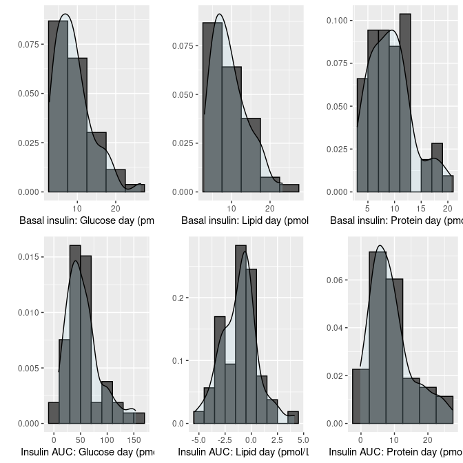

```r
> ### Insulin basal and Postpradial
> do.call(grid.arrange, c(hist.list[c(20:22, 29:31)], list(nrow = 2, ncol = 3)))
```

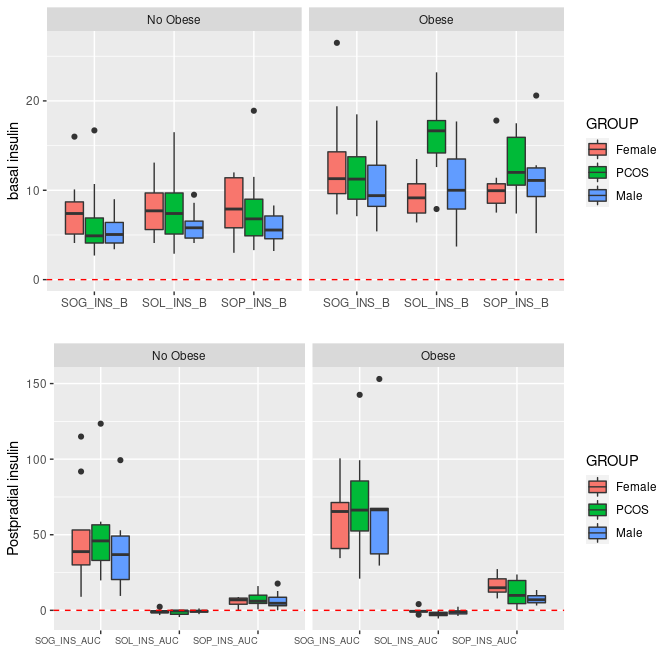

```r
> p1 <- bp.1.vars(general_data, c("SOG_INS_B", "SOL_INS_B", "SOP_INS_B"), "basal insulin")
> p2 <- bp.1.vars(general_data, c("SOG_INS_AUC", "SOL_INS_AUC", "SOP_INS_AUC"), "Postpradial insulin") +
+     theme(axis.text.x = element_text(angle = 0, vjust = 0.9, hjust = 1, size = 7))
> grid.arrange(p1, p2)
```

#### Glucose

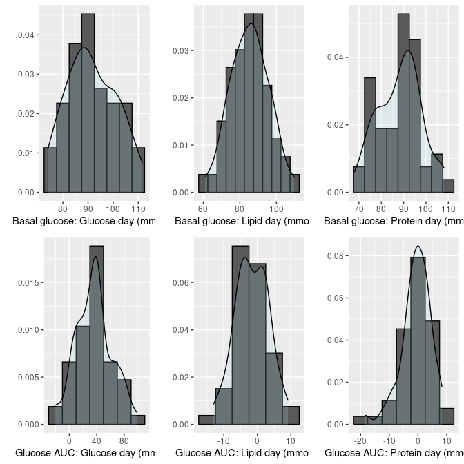

```r
> ### glucose basal and Postpradial
> do.call(grid.arrange, c(hist.list[c(23:25, 32:34)], list(nrow = 2, ncol = 3)))
```

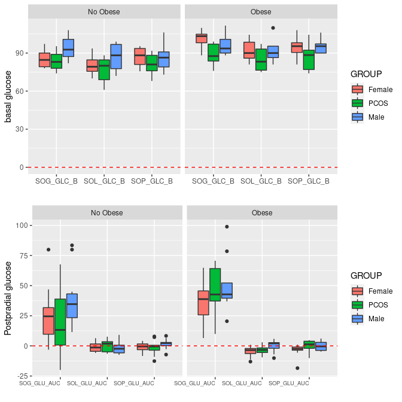

```r
> p1 <- bp.1.vars(general_data, c("SOG_GLC_B", "SOL_GLC_B", "SOP_GLC_B"), "basal glucose")
> p2 <- bp.1.vars(general_data, c("SOG_GLU_AUC", "SOL_GLU_AUC", "SOP_GLU_AUC"), "Postpradial glucose") +
+     theme(axis.text.x = element_text(angle = 0, vjust = 0.9, hjust = 1, size = 7))
> grid.arrange(p1, p2)
```

#### Triglicerids

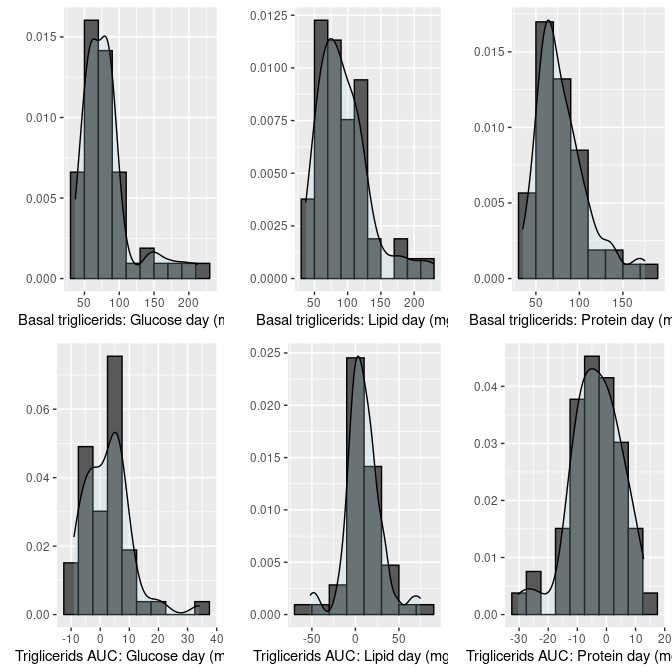

```r
> ## Triglicerids
> do.call(grid.arrange, c(hist.list[35:40], list(nrow = 2, ncol = 3)))
```

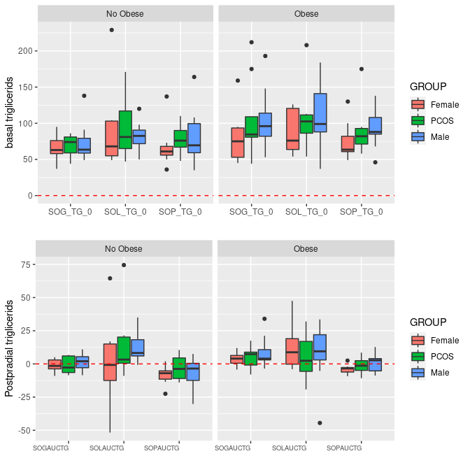

```r
> p1 <- bp.1.vars(general_data, c("SOG_TG_0", "SOL_TG_0", "SOP_TG_0"), "basal triglicerids")
> p2 <- bp.1.vars(general_data, c("SOGAUCTG", "SOLAUCTG", "SOPAUCTG"), "Postpradial triglicerids") +
+     theme(axis.text.x = element_text(angle = 0, vjust = 0.9, hjust = 1, size = 7))
> grid.arrange(p1, p2)
```

Distributions basal and Postpradial levels of triglicerids follow a right skewed distribution but a normal one on Postpradial levels on the load lipid and protein days. The triglicerids levels are higher at basal state than Postpradial. There are different distributions between groups across days in basal state. But these values are higher in obese subjects. Postpradial levels also, the distribution between groups is different each day, but lower on the protein load day. Although similar distributions across all subjects.

#### Cholesterol

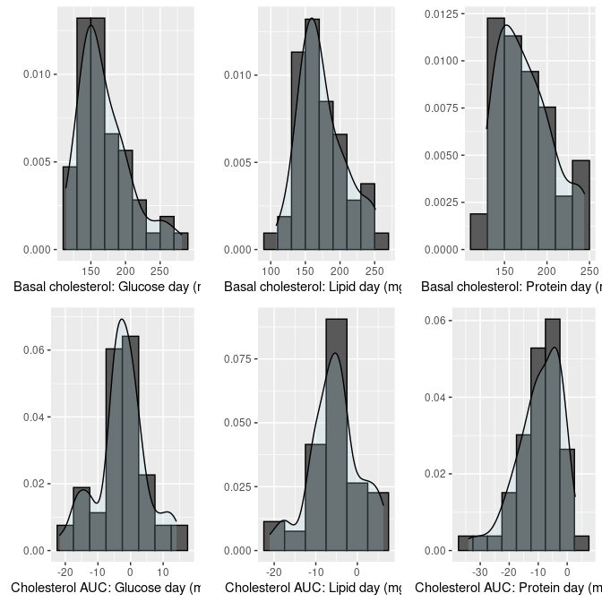

```r
> ### Cholesterol
> do.call(grid.arrange, c(hist.list[41:46], list(nrow = 2, ncol = 3)))
```

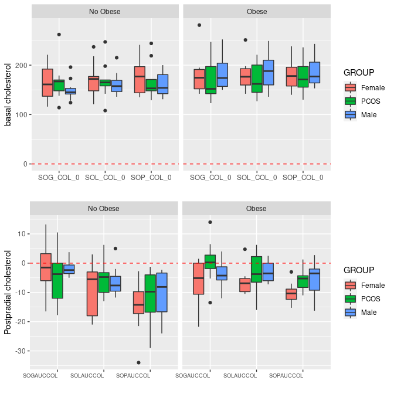

```r
> p1 <- bp.1.vars(general_data, c("SOG_COL_0", "SOL_COL_0", "SOP_COL_0"), "basal cholesterol")
> p2 <- bp.1.vars(general_data, c("SOGAUCCOL", "SOLAUCCOL", "SOPAUCCOL"), "Postpradial cholesterol") +
+     theme(axis.text.x = element_text(angle = 0, vjust = 0.9, hjust = 1, size = 7))
> grid.arrange(p1, p2)
```

Regarding the distributions, all of them seems to follow a normal one except basal cholesterol on day 1 and Postpradial cholesterol the 3th day being the first one right skewed and the lastone left skewed.

Basal levels of cholesterol are higher in obese subjects, though obese and non-obese females show a similar distribution, and PCOS and men show more variance. At Postpradial stage, the levels of cholesterolemia diminshes. With higher levels of cholesterol at the glucose and lipid load in women with PCOS.

#### HDL

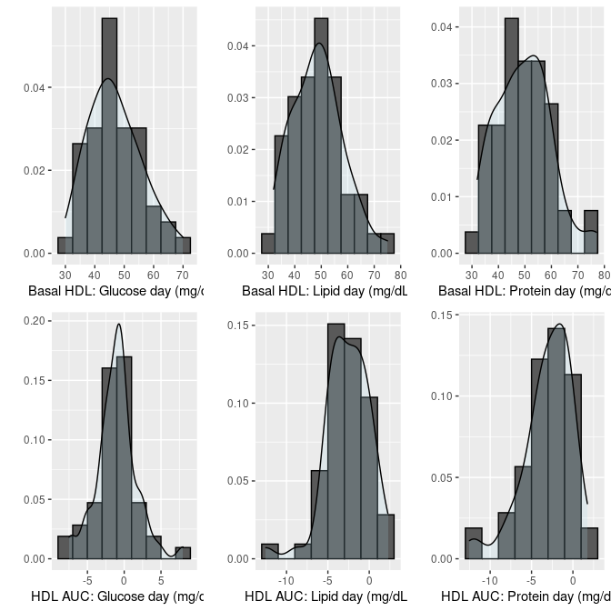

```r
> ### Cholesterol HDL
> do.call(grid.arrange, c(hist.list[47:52], list(nrow = 2, ncol = 3)))
```

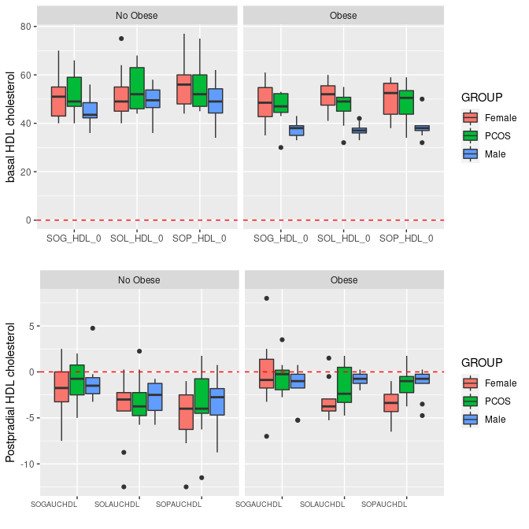

```r
> p1 <- bp.1.vars(general_data, c("SOG_HDL_0", "SOL_HDL_0", "SOP_HDL_0"), "basal HDL cholesterol")
> p2 <- bp.1.vars(general_data, c("SOGAUCHDL", "SOLAUCHDL", "SOPAUCHDL"), "Postpradial HDL cholesterol") +
+     theme(axis.text.x = element_text(angle = 0, vjust = 0.9, hjust = 1, size = 7))
> grid.arrange(p1, p2)
```

Regarding distribution of basal and Postpradial levels of HDL cholesterol, only the AUC of HDL on the glucose day follows a normal one. Basal levels show a slightly right skewed distribution, and the other AUC on the second and thirth day follow a left skewed distribution.

HDL distribution between groups, the data show a lower concentration of HDL cholesterol on obese subjects, and in general less HDL on men. With higher concentrations in PCOS non-obese patients and obese women. At Postpradial level, in general the subjects present lower concentrations than at the basal levels. At this stage, higher levels of HDL are present in obese subjects, with no clear pattern among the days.

#### LDL

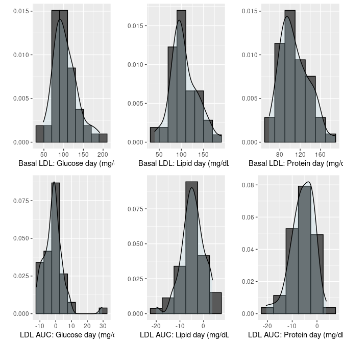

```r
> ### Cholesterol HDL
> do.call(grid.arrange, c(hist.list[53:58], list(nrow = 2, ncol = 3)))
```

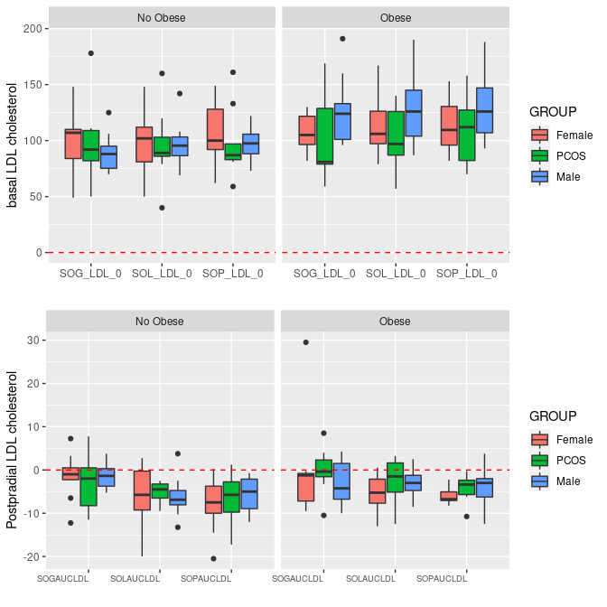

```r
> p1 <- bp.1.vars(general_data, c("SOG_LDL_0", "SOL_LDL_0", "SOP_LDL_0"), "basal LDL cholesterol")
> p2 <- bp.1.vars(general_data, c("SOGAUCLDL", "SOLAUCLDL", "SOPAUCLDL"), "Postpradial LDL cholesterol") +
+     theme(axis.text.x = element_text(angle = 0, vjust = 0.9, hjust = 1, size = 7))
> grid.arrange(p1, p2)
```

LDL cholesterol levels are higher at basal time on obese subjects, with more variance in general.Obese men have the highest values. At Postpradial stage, levels decreases in comparison with basal time. Ob obese subjects, on the 1st and 2d day, PCOS women show higher values of LDL cholesterol.

## Statistical multivariate descriptive analysis.

First of all let’s create a dataframe with the data.

```r
> X <- general_data[, 6:ncol(general_data)]  #data
```

```r
> plotPCA_methods <- function(X.list, factor, title1, title2, size = 1.5, glineas = 0.25,
+     labels.scores, labels.loads) {
+
+     X.scores <- X.list$scores
+     X.loadings <- X.list$loadings
+     colnames(X.scores) <- paste0("PC", 1:dim(X.scores)[2])
+
+     colnames(X.loadings) <- paste0("PC", 1:dim(X.loadings)[2])
+     varianza <- as.data.frame(X.list$var)
+     varianza$PC <- paste0("PC", 1:dim(X.loadings)[2])
+     colnames(varianza) <- c("varianza", "PC")
+     # scores
+     X.scores <- as.data.frame(X.scores)
+     Group <- factor[[1]]
+     Group2 <- factor[[2]]
+     colores <- 1:length(levels(Group))
+     # main plot
+     p1 <- ggplot(X.scores, aes(x = PC1, y = PC2)) + theme_classic() + geom_hline(yintercept = 0,
+         color = "gray70") + geom_vline(xintercept = 0, color = "gray70") + geom_point(aes(color = Group,
+         shape = Group2), alpha = 0.55, size = 3) + coord_cartesian(xlim = c(min(X.scores[,
+         1]) - 0.05, max(X.scores[, 1]))) + scale_fill_discrete(name = "Group")
+     # avoiding labels superposition
+
+     grafico <- p1 + geom_text_repel(aes(y = PC2, label = labels.scores), segment.size = 0.25,
+         size = size) + labs(x = c(paste("PC1", round(varianza[1, 1], 2), "%")), y = c(paste("PC2",
+         round(varianza[2, 1], 2), "%"))) + ggtitle(paste("Principal Component Analysis for: ",
+         title1, sep = " ")) + theme(plot.title = element_text(hjust = 0.5)) + scale_color_manual(values = colores)
+
+     X.loadings <- as.data.frame(X.loadings)
+     # main plot
+     p2 <- ggplot(X.loadings, aes(x = PC1, y = PC2)) + theme_classic() + geom_hline(yintercept = 0,
+         color = "gray70") + geom_vline(xintercept = 0, color = "gray70") + geom_point(aes(color = "gray70"),
+         alpha = 0.55, size = 3) + coord_cartesian(xlim = c(min(X.loadings[, 1]),
+         max(X.loadings[, 1])))
+     # avoiding labels superposition
+
+     grafico2 <- p2 + geom_text_repel(aes(label = labels.loads), segment.size = 0.25,
+         size = size) + labs(x = c(paste("PC1", round(varianza[1, 1], 2), "%")), y = c(paste("PC2",
+         round(varianza[2, 1], 2), "%"))) + ggtitle(paste("Principal Component Analysis for: ",
+         title2, sep = " ")) + theme(plot.title = element_text(hjust = 0.5)) + theme(legend.position = "none")
+
+     graficos <- list(grafico, grafico2)
+     return(graficos)
+ }
```

```r
> grupos <- list(general_data$GROUP, general_data$OBESE)
```

Because we are leading with more variables than observations, we are going to perform three approaches. 1. Simply by computing a PCA on the traspose data (prcomp and princomp) 2. Nipals algorithm 3. Sparse PCA

### prcomp and princomp

```r
> pcxt <- prcomp(t(X), center = T, scale = F)
> list.pcxt <- list(scores = pcxt$rot, loadings = pcxt$x, var = 100 * pcxt$sdev^2/sum(pcxt$sdev^2))
```

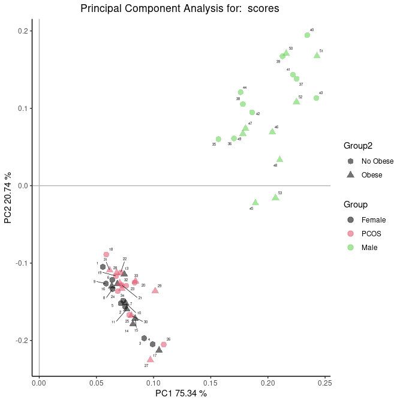

```r
> graficos <- plotPCA_methods(list.pcxt, factor = grupos, title1 = "scores ", title2 = "loadings",
+     labels.scores = rownames(X), labels.loads = colnames(X))
> graficos[[1]]
```

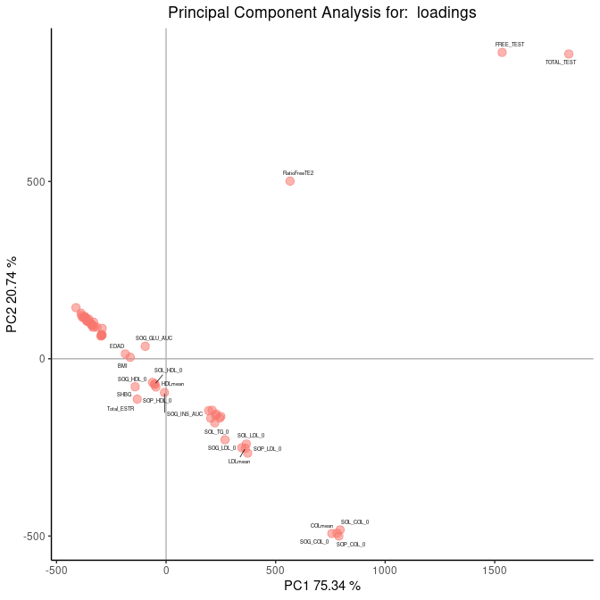

```r
> graficos[[2]]
```

### NIPALS

```r
> n <- nrow(X)
> pcx.nipals <- chemometrics::nipals(X, a = ncol(X), it = 200)
```

[output not shown]

[output cut: 2501 more lines]

[output not shown]

```r
> pcx.nipals_variance <- 100 * diag(t(pcx.nipals$T) %*% pcx.nipals$T)/sum(diag(t(pcx.nipals$T) %*%
+     pcx.nipals$T))
> list.nipals_1 <- list(scores = pcx.nipals$T, loadings = pcx.nipals$P, varianza = pcx.nipals_variance)
```

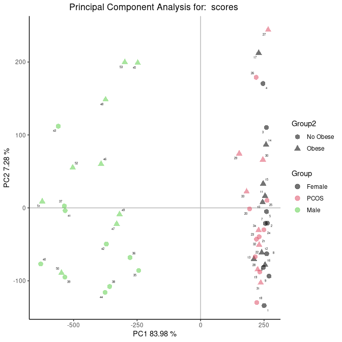

```r
> graficos <- plotPCA_methods(list.nipals_1, factor = grupos, title1 = "scores ", title2 = "loadings",
+     labels.scores = rownames(X), labels.loads = colnames(X))
> graficos[[1]]
```

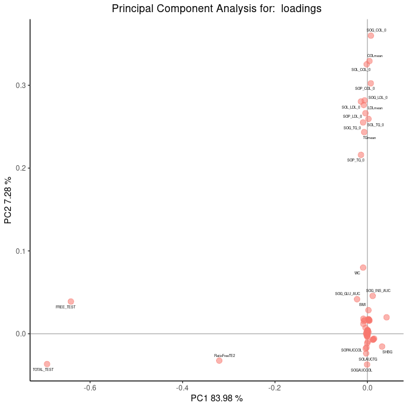

```r
> graficos[[2]]
```

### Sparse PCA

Let’s create a function to fix beta andcontrol sparsity.

```r
> perf <- function(X, X.pred) {
+
+     return(abs(norm(X - X.pred, type = "F"))/norm(X, type = "F"))
+
+ }
>
> spca.perf <- function(X, fix_parameter, transpose) {
+
+     parameter <- seq(1e-10, 1, 0.01)
+     perf.vector <- vector(mode = "numeric", length = length(parameter))
+     if (fix_parameter == "alpha") {
+
+         beta <- parameter
+         alpha <- 1e-04
+         if (transpose == F) {
+
+             for (i in 1:length(parameter)) {
+                 perf.vector[i] <- perf(as.matrix((X)), t(spca((X), alpha = alpha,
+                   beta = beta[i], verbose = F, k = ncol(X))$loadings))
+
+             }
+             beta <- beta[which.min(perf.vector)]
+             pcx <- spca(X, alpha = alpha, beta = beta, verbose = F, k = ncol(X))
+
+         } else if (transpose == T) {
+
+             for (i in 1:length(parameter)) {
+                 perf.vector[i] <- perf(as.matrix(t(X)), (spca(t(X), alpha = alpha,
+                   beta = beta[i], verbose = F, k = ncol(X))$scores))
+
+             }
+             beta <- beta[which.min(perf.vector)]
+             pcx <- spca(t(X), alpha = alpha, beta = beta, verbose = F, k = ncol(X))
+         }
+
+     } else if (fix_parameter == "beta") {
+
+         alpha <- parameter
+         beta <- 1e-04
+         if (transpose == F) {
+
+             for (i in 1:length(parameter)) {
+                 perf.vector[i] <- perf(as.matrix((X)), t(spca((X), alpha = alpha[i],
+                   beta = beta, verbose = F, k = ncol(X))$loadings))
+
+             }
+             alpha <- alpha[which.min(perf.vector)]
+             pcx <- spca(X, alpha = alpha, beta = beta, verbose = F, k = ncol(X))
+         } else if (transpose == T) {
+
+             for (i in 1:length(parameter)) {
+                 perf.vector[i] <- perf(as.matrix(t(X)), (spca(t(X), alpha = alpha[i],
+                   beta = beta, verbose = F, k = ncol(X))$scores))
+
+             }
+
+             alpha <- alpha[which.min(perf.vector)]
+             pcx <- spca(t(X), alpha = alpha, beta = beta, verbose = F, k = ncol(X))
+         }
+
+
+     }
+
+     return(pcx)
+ }
```

```r
> # pcx.a <- spca.perf(X,'beta',transpose = F) pcx.a.t <-
> # spca.perf(X,'beta',transpose=T)
> pcx.b <- spca.perf(X, "alpha", transpose = F)
> pcx.b.t <- spca.perf(X, "alpha", transpose = T)
```

```r
> lista.spca.b <- list(loadings = (pcx.b$loadings), scores = t(pcx.b$scores), var = 100 *
+     round(pcx.b$eigenvalues/sum(pcx.b$eigenvalues), 2))
> lista.spca.b.t <- list(loadings = (pcx.b.t$scores), scores = pcx.b.t$loadings, var = 100 *
+     round(pcx.b.t$eigenvalues/sum(pcx.b.t$eigenvalues), 2))
```

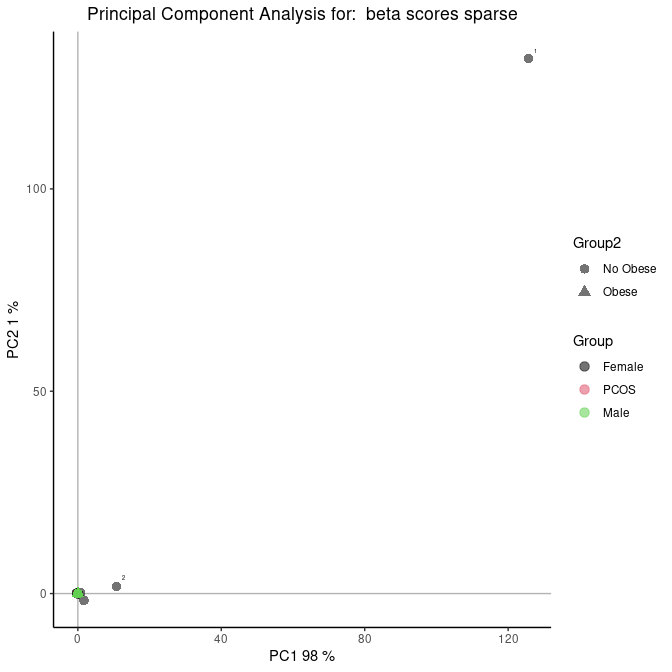

```r
> g1 <- plotPCA_methods(lista.spca.b, grupos, title1 = "beta scores sparse", title2 = "beta loads sparse",
+     labels.loads = colnames(X), labels.scores = rownames(X))
> g1[[1]]
```

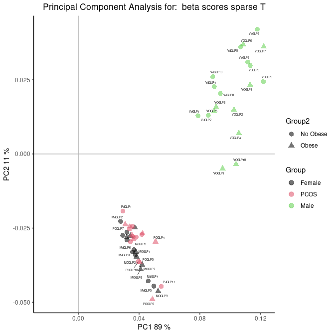

```r
> g2 <- plotPCA_methods(lista.spca.b.t, grupos, title1 = "beta scores sparse T", title2 = "beta loads sparse T",
+     labels.loads = colnames(X), labels.scores = general_data$Paciente)
>
> g2[[1]]
```